# Zhang_TianyuHW2

Tianyu Zhang

2024-02-09

## Introduction of Project

### Motivation

Public transit access is increasingly relevant in cities, particularly for metropolitans like Chicago. Besides the convenience they bring, they also define neighborhoods with transit-oriented development and reshape local socioeconomic and demographic profiles. By choosing Chicago as a case study, the following report investigates whether households place more value on transit-rich neighborhood (TODs) compared to other neighborhoods (Non-TODs). To identify TODs, the study creates a 1-mile unioned buffer from CTA L Line points, and classify neighborhoods with centroids located within the buffer as TODs.

Data sources for this study include 2009 5-Year American Community Survey and 2019 5-Year American Community Survey. Additional shapefiles, including Chicago municipal boundary and CTA L Line station locations, are downloaded from Chicago Data Portal (https://data.cityofchicago.org/).

## Data Preparation

### Install Packages

```r
library(tidyverse)
library(tidycensus)
library(sf)
library(kableExtra)
library(tmap)
library(scales)

options(scipen=999)
options(tigris_class = "sf")
```

### Getting 5-Year ACS data for Cook County 2009 and 2019

After the variables are retrieved, they are converted to Chicago’s CRS: NAD83 StatePlane Illinois East FIPS 1201 (EPSG 26971) (ESRI:103270).

#### 5-Year ACS 2009

```r
invisible(capture.output({
tracts09 <-
  get_acs(geography = "tract",
          variables = c("B25026_001E","B02001_002E",
                        "B15001_050E","B15001_009E",
                        "B19013_001E", "B25058_001E",
                        "B06012_002E"),
          year=2009, state=17,
          county=031, geometry=TRUE)%>%
  st_transform('ESRI:103270')

tracts09 <-
  tracts09 %>%
  dplyr::select( -NAME, -moe) %>%
  spread(key = variable, value = estimate) %>%
  rename(TotalPop = B25026_001,
         Whites = B02001_002,
         FemaleBachelors = B15001_050,
         MaleBachelors = B15001_009,
         MedHHInc = B19013_001,
         MedRent = B25058_001,
         TotalPoverty = B06012_002)

tracts09 <-
  tracts09 %>%
  mutate(pctWhite = ifelse(TotalPop > 0, Whites / TotalPop, 0),
         pctBachelors = ifelse(TotalPop > 0, ((FemaleBachelors + MaleBachelors) / TotalPop), 0),
         pctPoverty = ifelse(TotalPop > 0, TotalPoverty / TotalPop, 0),
         year = "2009") %>%
  dplyr::select(-Whites,-FemaleBachelors,-MaleBachelors,-TotalPoverty)
}))
```

#### 5-Year ACS 2019

```r
invisible(capture.output({
tracts19 <-
  get_acs(geography = "tract",
          variables = c("B25026_001E","B02001_002E",
                        "B15001_050E","B15001_009E",
                        "B19013_001E", "B25058_001E",
                        "B06012_002E"),
          year=2019, state=17,
          county=031, geometry=TRUE)%>%
  st_transform('ESRI:103270')

tracts19 <-
  tracts19 %>%
  dplyr::select( -NAME, -moe) %>%
  spread(key = variable, value = estimate) %>%
  rename(TotalPop = B25026_001,
         Whites = B02001_002,
         FemaleBachelors = B15001_050,
         MaleBachelors = B15001_009,
         MedHHInc = B19013_001,
         MedRent = B25058_001,
         TotalPoverty = B06012_002)

tracts19 <-
  tracts19 %>%
  mutate(pctWhite = ifelse(TotalPop > 0, Whites / TotalPop, 0),
         pctBachelors = ifelse(TotalPop > 0, ((FemaleBachelors + MaleBachelors) / TotalPop), 0),
         pctPoverty = ifelse(TotalPop > 0, TotalPoverty / TotalPop, 0),
         year = "2019") %>%
  dplyr::select(-Whites,-FemaleBachelors,-MaleBachelors,-TotalPoverty)
}))
```

#### Combining 2009 and 2019 5-Year ACS data

```r
CookTracts <- rbind(tracts09,tracts19)
```

### Clipping Cook Tracts to Chicago

Since only county-level data is retrieved from the previous process, this section clips the dataset to Chicago’s geographic boundary to focus the study on the city.

#### Getting Chicago Shapefile

```r
invisible(capture.output({
Chicago <- st_read("C:/Users/ztyuu/Documents/Spring2024/PPA/Week3_4/Boundaries - City") %>%
  st_transform(st_crs(CookTracts))
st_crs(Chicago)
}))
```

#### Clipping Tracts to City

```r
invisible(capture.output({
ChicagoTracts <-
  st_intersection(CookTracts, Chicago) %>%
  mutate(Selection_Type = "Clip")
}))
```

#### Getting CTA L Line Transit Data

```r
invisible(capture.output({
Lline <- st_read("C:/Users/ztyuu/Documents/Spring2024/PPA/Week3_4/CTA_RailStations") %>%
  st_transform(st_crs(ChicagoTracts))
}))
```

### Relating L Line and Chicago Census Tracts

A 1-mile buffer around each L Line station is created and unioned as L Line’s transit corridor. Note: NAD83 StatePlane Illinois East FIPS 1201 measures distance in meters.

#### Creating L Line Buffer

```r
invisible(capture.output({
st_crs(Lline)

Lline_Buffer <- st_union(st_buffer(Lline, 1609.344))
}))
```

Assuming that the centroids of each census tract is most representative of community’s average activity center, the study categorizes every census tract with its centroid contained by the L Line buffer to be a TOD, while the rest are Non-TODs.

#### Locating TODs and Non-TODs

```r
ChicagoTracts.group <-
  rbind(
      st_centroid(ChicagoTracts)[Lline_Buffer,] %>%
      st_drop_geometry() %>%
      left_join(ChicagoTracts) %>%
      st_sf() %>%
      mutate(TOD = "TOD"),
    st_centroid(ChicagoTracts)[Lline_Buffer, op = st_disjoint] %>%
      st_drop_geometry() %>%
      left_join(ChicagoTracts) %>%
      st_sf() %>%
      mutate(TOD = "Non-TOD")) %>%
  mutate(MedRent.inf = ifelse(year == "2009", MedRent * 1.19, MedRent),
         MedHHInc.inf = ifelse(year == "2009", MedHHInc * 1.19, MedHHInc))
```

## Plotting spatial-temporal change in variables

The following section visualizes spatial-temporal differences between variables by TOD/Non-TOD categorization and year (2009 and 2019).

### Locating TODs and Non-TOD with reference to CTA L Line stations

Fig.1 indicates where TODs and Non-TODs locate with reference to CTA L Line stations. It suggests that a greater number of TODs concentrate around central Chicago, particularly the Loop area. Comparatively, most suburban tracts are classified as Non-TODs.

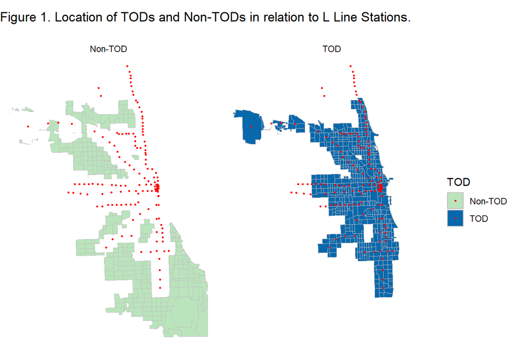

```r
ggplot() +
  geom_sf(data = ChicagoTracts.group, aes(fill = TOD), color = "grey") +
  geom_sf(data=Lline, show.legend = "point", size = 0.5, color = "red") +
  scale_fill_manual(values = c("#bae4bc", "#0868ac"))+
  labs(title = "Figure 1. Location of TODs and Non-TODs in relation to L Line Stations.") +
  theme_void() +
  theme(plot.title = element_text(margin = margin(b = 20)))+
  facet_wrap(~TOD)
```

### 1. Median Rent

Fig.2 shows that in both 2009 and 2019, TODs tend to have higher tract-level median rent, especially for tracts in downtown and north Chicago. Temporally, median rent has also increased more significantly in TODs than Non-TODs between 2009 and 2019. These observations indicate that higher rents in TODs are continuously reinforced.

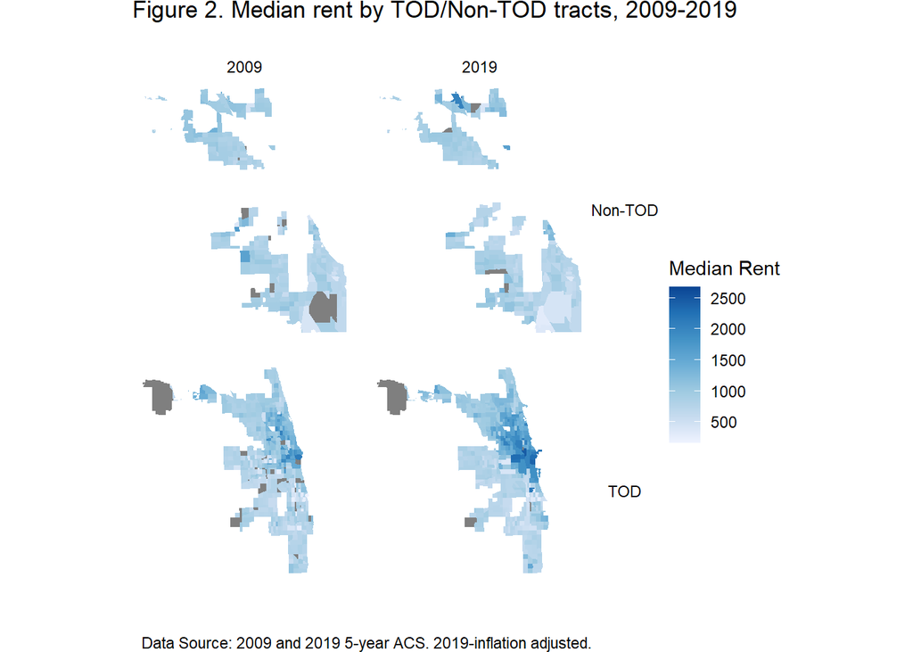

```r
ggplot() +
  geom_sf(data = ChicagoTracts.group, aes(fill = MedRent.inf), color = NA) +
  scale_fill_distiller(palette = "Blues", direction = 1) +
  labs(title = "Figure 2. Median rent by TOD/Non-TOD tracts, 2009-2019", fill = "Median Rent", caption = "Data Source: 2009 and 2019 5-year ACS. 2019-inflation adjusted.") +
  theme_void() +
  theme(plot.caption = element_text(hjust = 1), plot.title = element_text(margin = margin(b = 20)))+
  facet_grid(TOD~year)
```

### 2. Median Household Income

Similar to fig. 2, fig. 3 also indicates that in both 2009 and 2019, TODs have higher tract-level median household income compared to Non-TODs, which is particularly true for downtown and north Chicago. Temporally, TODs in north Chicago has significantly become wealthier, while Non-TODs in South Chicago has become less well-off. These observations indicate that TODs outpaces Non-TODs in attracting wealthier communities.

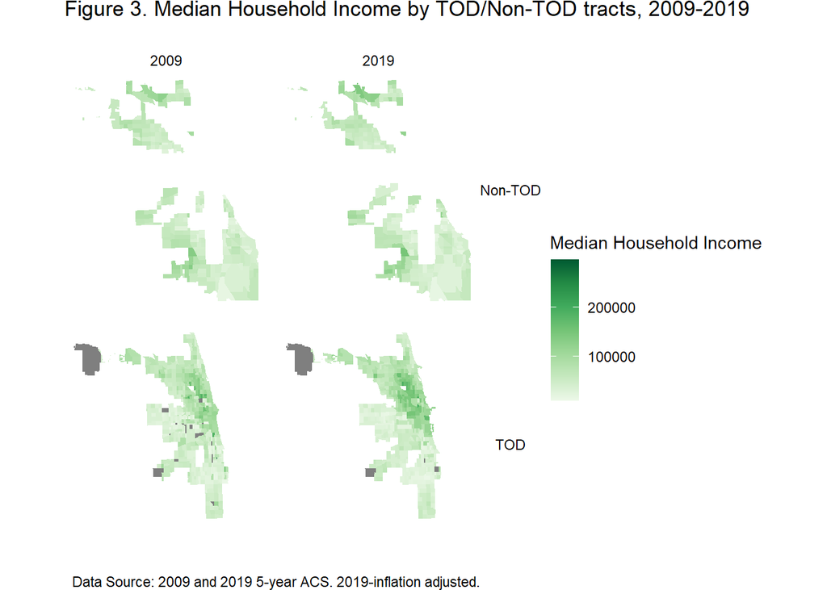

```r
ggplot() +
  geom_sf(data = ChicagoTracts.group, aes(fill = MedHHInc.inf), color = NA) +
  scale_fill_distiller(palette = "Greens", direction = 1) +
  labs(title = "Figure 3. Median Household Income by TOD/Non-TOD tracts, 2009-2019", fill = "Median Household Income", caption = "Data Source: 2009 and 2019 5-year ACS. 2019-inflation adjusted.") +
  theme_void() + theme(plot.caption = element_text(hjust = 1), plot.title = element_text(margin = margin(b = 20)))+
  facet_grid(TOD~year)
```

### 3. Total Population

Fig. 4 indicates a general pattern of decreasing population in Chicago between 2009 and 2019, particularly for Non-TODs. While total population differences between tracts were more evident in 2009, the pattern events out in 2019. As a result, while higher populations live in Non-TODs compared to TODs in 2009, the difference is less significant in 2019. The Loop area, however, by ranking top under the population metric in 2019, has observed exceedingly high population growth. These observations indicate that more people are moving from Non-TODs to TODs.

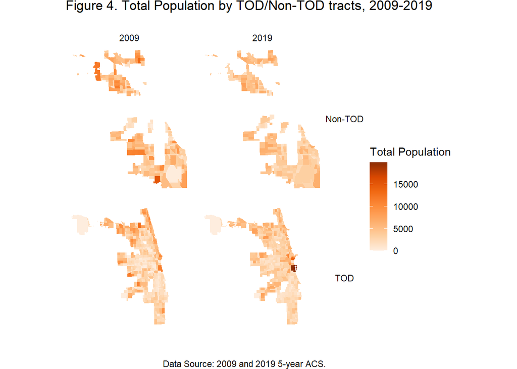

```r
ggplot() +
  geom_sf(data = ChicagoTracts.group, aes(fill = TotalPop), color = NA) +
  scale_fill_distiller(palette = "Oranges", direction = 1) +
  labs(title = "Figure 4. Total Population by TOD/Non-TOD tracts, 2009-2019", fill = "Total Population", caption = "Data Source: 2009 and 2019 5-year ACS.") +
  theme_void() + theme(plot.title = element_text(margin = margin(b = 20)))+
  facet_grid(TOD~year)
```

Fig. 5 shows a consistent pattern of TODs having better-educated communities (individuals with bachelor degree) than Non-TODs. The temporal change between 2009 and 2019, however, is minimal.

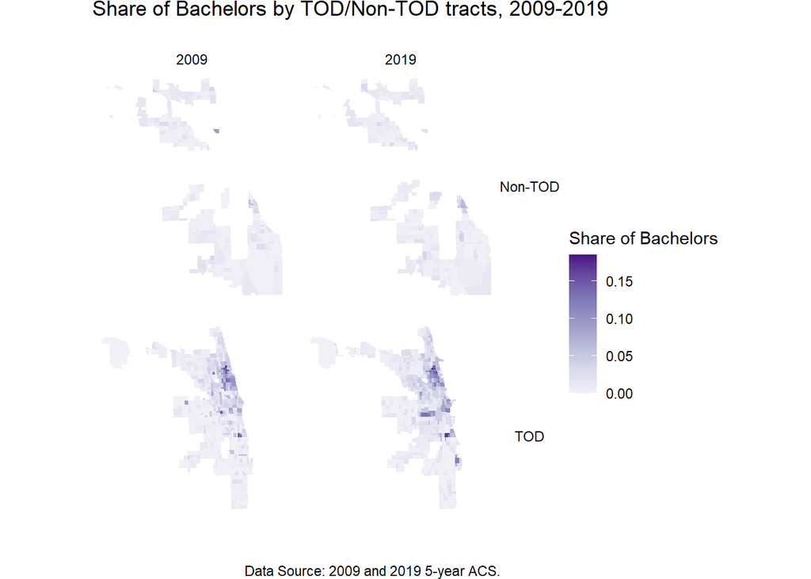

```r
ggplot() +
  geom_sf(data = ChicagoTracts.group, aes(fill = pctBachelors), color = NA) +
  scale_fill_distiller(palette = "Purples", direction = 1, limits = c(0, 0.185)) +
  labs(title = "Share of Bachelors by TOD/Non-TOD tracts, 2009-2019", fill = "Share of Bachelors", caption = "Data Source: 2009 and 2019 5-year ACS.") +
  theme_void() + theme(plot.title = element_text(margin = margin(b = 20)))+
  facet_grid(TOD~year)
```

## Indicator Table

```r
ChicagoTracts.summary <-
  st_drop_geometry(ChicagoTracts.group) %>%
  group_by(year, TOD) %>%
  summarize(
    Rent = mean(MedRent.inf, na.rm = TRUE),
    Population = mean(TotalPop, na.rm = TRUE),
    Household_Income = mean(MedHHInc, na.rm = TRUE),
    Percent_Bach = mean(pctBachelors, na.rm = TRUE)
  )

ChicagoTracts.summary %>%
  unite(year.TOD, year, TOD, sep = ": ", remove = T) %>%
  gather(Variable, Value, -year.TOD) %>%
  mutate(Value = round(Value, 3)) %>%
  spread(year.TOD, Value) %>%
  kable() %>%
  kable_styling(full_width = FALSE, position = "center") %>%
  add_header_above(
    header = c("Table 1. Differences between variable means by Non-TOD and TOD census tracts, 2009-2019." = 5),
    align = "center",
    escape = FALSE
  ) %>%
  footnote(
    general_title = "\n",
    general = "Data Source: 2009 and 2019 5-year ACS. 2019-inflation adjusted."
  )
```

| Table 1. Differences between variable means by Non-TOD and TOD census tracts, 2009-2019. Variable | Table 1. Differences between variable means by Non-TOD and TOD census tracts, 2009-2019. 2009: Non-TOD | Table 1. Differences between variable means by Non-TOD and TOD census tracts, 2009-2019. 2009: TOD | Table 1. Differences between variable means by Non-TOD and TOD census tracts, 2009-2019. 2019: Non-TOD | Table 1. Differences between variable means by Non-TOD and TOD census tracts, 2009-2019. 2019: TOD |
| --- | --- | --- | --- | --- |
| Household_Income | 47319.816 | 49056.159 | 56299.584 | 63918.580 |
| Percent_Bach | 0.008 | 0.018 | 0.009 | 0.024 |
| Population | 4310.056 | 2789.235 | 3918.691 | 3131.267 |
| Rent | 867.583 | 913.164 | 889.032 | 1054.748 |

## Indicator Plots

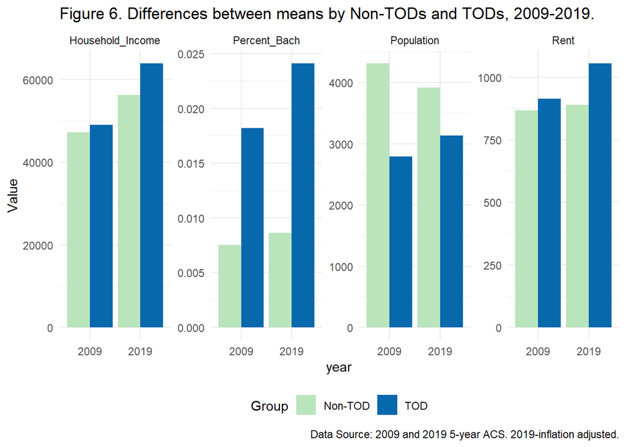

```r
ChicagoTracts.summary %>%
  gather(Variable, Value, -year, -TOD) %>%
  ggplot(aes(year, Value, fill = TOD)) +
  geom_bar(stat = "identity", position = "dodge") +
  facet_wrap(~Variable, scales = "free", ncol=5) +
  scale_fill_manual(values = c("#bae4bc", "#0868ac")) +
  labs(title = "Figure 6. Differences between means by Non-TODs and TODs, 2009-2019.", fill = "Group", caption = "Data Source: 2009 and 2019 5-year ACS. 2019-inflation adjusted.") +
  theme_minimal()+ theme(legend.position="bottom")
```

In conclusion, the study confirms a general pattern that TODs are valued more by Chicago communities. This pattern is most outstanding near the Loop area in downtown Chicago.

## Citations

“Boundaries - City,” City of Chicago, updated Dec 12, 2023. https://data.cityofchicago.org/d/ewy2-6yfk?category=Facilities-Geographic-Boundaries&view_name=Boundaries-City.

“CTA-L-Rail-Stations-Shapefile,” Chicago Transit Authority, updated November 17, 2023. https://data.cityofchicago.org/dataset/CTA-L-Rail-Stations-Shapefile/vmyy-m9qj/about_data.